# **CHURN PREDICTION**

#### **The output column(Churn) is plotted with all other columns.**

```python
# Facetgrid for International plan and Churn columns
```

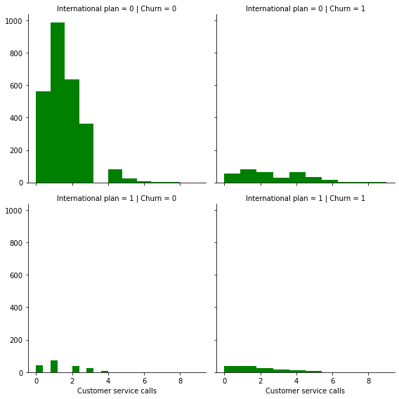

```python
plt.figure(figsize=(15,10))
g = sns.FacetGrid(d,row='International plan',col='Churn',height=4)
g =g.map(plt.hist,"Customer service calls",color='g')
```

- **The customers having sinlge Customer service call,who doesn't have International plan and did not cancel the subscription are more.**

# DATA SPLITTING

- Dividing the data set into input and output

```python
# 'X' -> i/p col ........... 'y' -> o/p col
X=d.drop(['Churn','State'],axis=1)
y=d.Churn
```

```python
# Splitting the data into Training set and Testing set
```

```python
X_train,X_test,y_train,y_test= train_test_split(X,y, test_size=0.2,random_state=1)
print(X_train.shape)
print(X_test.shape)
print(y_train.shape)
print(y_test.shape)
```

```
(2666, 18)
(667, 18)
(2666,)
(667,)
```

- Scaling the data

```python
scaler=StandardScaler()
```

```python
# Scaling of training data
```

```python
warnings.filterwarnings("ignore")
scaled_X_train = pd.DataFrame(scaler.fit_transform(X_train),columns=X_train.columns)
scaled_X_train.head()
```

|  | Account length | Area code | International plan | Voice mail plan | Number vmail messages | Total day minutes | Total day calls | Total day charge | Total eve minutes | Total eve calls | Total eve charge | Total night minutes | Total night calls | Total night charge | Total intl minutes | Total intl calls | Total intl charge | Customer service calls |
| --- | --- | --- | --- | --- | --- | --- | --- | --- | --- | --- | --- | --- | --- | --- | --- | --- | --- | --- |
| 0 | 1.394174 | -0.682930 | -0.330827 | -0.626232 | -0.598973 | 1.097372 | -1.647677 | 1.096881 | -0.954298 | -0.109104 | -0.953197 | 0.953346 | -1.452839 | 0.955473 | -0.011103 | 0.605786 | -0.017022 | 0.324877 |
| 1 | -0.358227 | -0.682930 | -0.330827 | -0.626232 | -0.598973 | 1.042197 | 1.158819 | 1.041705 | 0.412778 | -0.661135 | 0.412504 | -0.543701 | -0.990058 | -0.543076 | 0.273176 | -0.596466 | 0.272527 | -0.429585 |
| 2 | -0.358227 | -0.682930 | -0.330827 | -0.626232 | -0.598973 | 0.096852 | 0.912635 | 0.097225 | -0.182371 | -0.861873 | -0.181379 | -0.015681 | -0.218757 | -0.015727 | -1.290359 | -0.195715 | -1.293670 | -0.429585 |
| 3 | -0.458364 | -0.516575 | -0.330827 | -0.626232 | -0.598973 | -0.390535 | 0.174083 | -0.390703 | 0.014048 | -0.109104 | 0.015041 | 0.557825 | -1.401419 | 0.559962 | -0.259847 | -0.596466 | -0.253926 | 0.324877 |
| 4 | -0.057816 | -0.682930 | -0.330827 | -0.626232 | -0.598973 | 0.181454 | 0.075610 | 0.181611 | -0.854124 | 0.342558 | -0.853831 | 1.398308 | -0.424437 | 1.399325 | 0.344246 | -0.195715 | 0.338334 | 0.324877 |

```python
# Scaling of test data
```

```python
warnings.filterwarnings("ignore")
scaled_X_test = pd.DataFrame(scaler.transform(X_test),columns=X_test.columns)
scaled_X_test.head()
```

|  | Account length | Area code | International plan | Voice mail plan | Number vmail messages | Total day minutes | Total day calls | Total day charge | Total eve minutes | Total eve calls | Total eve charge | Total night minutes | Total night calls | Total night charge | Total intl minutes | Total intl calls | Total intl charge | Customer service calls |
| --- | --- | --- | --- | --- | --- | --- | --- | --- | --- | --- | --- | --- | --- | --- | --- | --- | --- | --- |
| 0 | -1.309531 | 1.741111 | -0.330827 | -0.626232 | -0.598973 | -1.124373 | -1.549204 | -1.124217 | 1.408623 | -0.410211 | 1.408472 | 0.269095 | 2.712187 | 0.269920 | 0.770665 | 1.006536 | 0.772657 | 0.324877 |
| 1 | 1.494311 | -0.516575 | 3.022728 | -0.626232 | -0.598973 | -0.449389 | 0.666451 | -0.449124 | -0.418074 | -1.865566 | -0.417084 | -0.419112 | 0.758224 | -0.420028 | 0.308711 | 1.808038 | 0.312011 | 0.324877 |
| 2 | -1.084222 | -0.516575 | -0.330827 | -0.626232 | -0.598973 | -0.572615 | 2.192791 | -0.572458 | -0.099875 | 0.242189 | -0.100500 | 0.172192 | 0.398284 | 0.173239 | 1.659037 | -0.596466 | 1.654466 | -0.429585 |
| 3 | 0.392802 | -0.682930 | -0.330827 | -0.626232 | -0.598973 | 0.072942 | -0.170574 | 0.073423 | 2.946584 | -1.012427 | 2.947485 | 0.296781 | -0.527278 | 0.296287 | -0.544126 | -0.195715 | -0.543475 | -0.429585 |
| 4 | 0.292665 | -0.516575 | -0.330827 | -0.626232 | -0.598973 | 1.088176 | -2.632413 | 1.088226 | 1.597185 | 0.493112 | 1.597960 | 0.743720 | -0.630118 | 0.744534 | -0.544126 | -0.596466 | -0.543475 | 0.324877 |

# CLASSIFICATION USING ALGORITHMS

- K- Nearest Neighbors(KNN) Classifier

  The KNN algorithm is a non-parametric used for classification and regression. In both cases, the input consists of the k closest training examples in the feature space. ... In k-NN classification, the output is a class membership.

```python
# Checking for optimum K value
```

```python
scores=[]
for k in range(1, 20):
    knn_model = KNeighborsClassifier(n_neighbors=k)
    knn_model.fit(scaled_X_train, y_train)
    pred_test = knn_model.predict(scaled_X_test)
    scores.append(accuracy_score(y_test, pred_test))
scores
```

```
[0.8755622188905547,
 0.8920539730134932,
 0.904047976011994,
 0.9025487256371814,
 0.9115442278860569,
 0.9070464767616192,
 0.904047976011994,
 0.8995502248875562,
 0.9085457271364318,
 0.8980509745127436,
 0.9010494752623688,
 0.8935532233883059,
 0.896551724137931,
 0.8980509745127436,
 0.8980509745127436,
 0.8980509745127436,
 0.8980509745127436,
 0.8980509745127436,
 0.8980509745127436]
```

```python
# Plot of K values and Scores
```

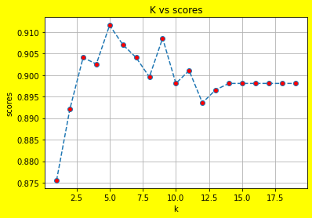

```python
fig = plt.figure()
fig.patch.set_facecolor('yellow')
plt.plot(range(1,20), scores, marker='o', markerfacecolor='r', linestyle='--')
plt.xlabel("k")
plt.ylabel("scores")
plt.title("K vs scores")
plt.grid()
```

```python
# Model Building
```

```python
knn = KNeighborsClassifier(n_neighbors=5, metric='euclidean')
knn.fit(scaled_X_train, y_train)
```

```
KNeighborsClassifier(metric='euclidean')
```

```python
# Prediction on  training data
train_pred_1 = knn.predict(scaled_X_train)
print("Prediction on training data\n",train_pred_1)

# Prediction on  testing data
test_pred_1 = knn.predict(scaled_X_test)
print("\nPrediction on testing data\n",test_pred_1)
```

```
Prediction on training data
 [0 0 0 ... 0 0 0]

Prediction on testing data
 [0 0 0 0 0 0 0 0 1 0 0 0 0 0 0 0 0 0 0 0 0 0 0 0 0 0 0 0 0 0 0 0 0 0 0 0 0
 0 0 0 0 0 0 0 0 0 0 0 0 1 1 0 0 0 0 0 0 0 0 0 0 0 1 0 0 0 0 0 0 0 0 0 0 1
 0 0 0 0 0 0 0 0 0 0 0 0 0 0 1 0 0 0 0 0 0 0 0 0 0 0 0 0 0 0 0 0 0 0 0 0 0
 1 0 0 0 0 0 0 0 0 0 0 0 0 0 0 0 0 0 0 0 0 0 0 0 0 0 0 0 0 0 0 0 0 0 0 0 0
 0 0 0 0 0 0 0 0 0 0 0 0 0 0 0 0 0 0 0 0 0 0 0 0 0 1 0 1 0 0 0 0 1 0 0 1 0
 0 0 0 0 0 0 0 0 0 1 0 0 0 0 0 0 1 0 0 0 0 0 0 0 0 0 0 0 0 0 0 0 1 0 0 0 0
 0 1 0 0 0 0 0 0 0 0 0 0 0 0 0 0 0 0 0 1 0 0 0 0 0 0 0 1 0 0 0 0 1 0 0 0 0
 0 0 0 0 0 0 0 0 0 0 0 0 0 0 0 0 0 0 0 0 0 0 0 0 0 0 0 0 0 0 0 0 0 0 0 0 0
 0 0 0 0 0 0 0 1 0 0 1 1 0 0 1 0 0 0 1 0 0 0 0 0 0 0 0 0 0 0 0 0 0 0 0 0 0
 0 0 0 0 0 0 0 0 0 0 0 0 0 0 0 0 0 0 0 0 0 0 0 0 1 0 0 0 0 0 0 0 0 0 0 0 0
 0 0 0 0 0 0 0 0 0 0 0 0 1 0 0 0 0 0 0 0 0 0 0 0 0 0 0 0 0 0 0 0 0 0 0 0 0
 0 1 0 0 0 0 0 0 0 0 0 0 0 0 0 0 0 0 0 0 0 0 0 0 0 0 0 1 0 0 0 0 0 0 0 0 0
 0 0 0 0 0 0 0 0 0 0 0 0 0 0 0 0 0 0 0 0 0 0 0 0 1 0 0 1 0 0 0 0 0 0 0 0 0
 0 1 0 0 0 0 0 0 0 1 0 0 0 0 0 0 1 0 0 0 0 0 0 0 0 0 0 0 0 0 0 0 0 0 0 0 1
 0 0 0 0 0 0 0 0 0 0 0 1 0 0 0 0 0 0 0 0 0 0 1 0 0 0 0 0 0 0 0 0 0 0 0 0 0
 0 0 0 0 1 0 0 0 0 0 0 0 0 0 0 0 0 0 0 0 1 0 0 0 1 0 0 0 0 0 0 0 0 0 0 1 0
 0 0 0 0 0 0 0 0 0 0 0 0 0 0 0 0 0 0 0 0 0 0 0 0 0 0 0 0 1 0 0 0 0 0 0 0 0
 0 0 0 0 0 0 0 0 0 0 0 0 0 0 0 0 0 0 0 0 0 0 0 0 0 0 0 0 0 1 0 0 0 0 0 0 0
 0]
```

```python
# Confusion matrix for training data
```

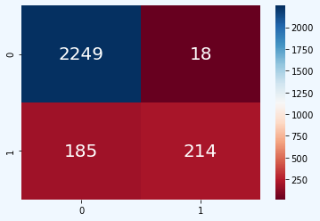

```python
fig = plt.figure()
fig.patch.set_facecolor('aliceblue')
sns.heatmap(confusion_matrix(y_train, train_pred_1), annot=True,fmt='d', annot_kws={'size':20},cmap='RdBu')
```

```python
# Confusion matrix for testing data
```

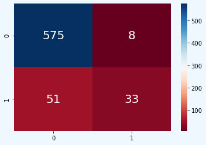

```python
fig = plt.figure()
fig.patch.set_facecolor('aliceblue')
sns.heatmap(confusion_matrix(y_test, test_pred_1), annot=True, fmt='d',annot_kws = {'size':20},cmap="RdBu")
```

```python
# Classification report for Training and testing data
```

```python
print("Classification Report for Training Data\n",classification_report(y_train, train_pred_1))
print("\nClassification Report for Test Data\n",classification_report(y_test, test_pred_1))
```

```
Classification Report for Training Data
               precision    recall  f1-score   support

           0       0.92      0.99      0.96      2267
           1       0.92      0.54      0.68       399

    accuracy                           0.92      2666
   macro avg       0.92      0.76      0.82      2666
weighted avg       0.92      0.92      0.92      2666


Classification Report for Test Data
               precision    recall  f1-score   support

           0       0.92      0.99      0.95       583
           1       0.80      0.39      0.53        84

    accuracy                           0.91       667
   macro avg       0.86      0.69      0.74       667
weighted avg       0.90      0.91      0.90       667
```

- **As the output column is imbalanced, we consider f1-score**
  - Train : 92%
  - Test : 91%

```python
# roc-auc curve for KNN classifier
```

```
0.834681042228212
```

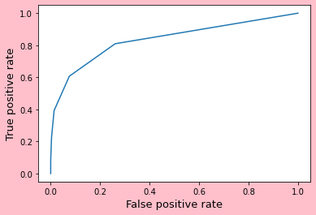

```python
plt.figure(facecolor='pink')
k_prob=knn.predict_proba(scaled_X_test)[:,1]
fpr,tpr,threshold=roc_curve(y_test,k_prob,pos_label=1)

plt.plot(fpr,tpr)
plt.xlabel("False positive rate",fontsize=13)
plt.ylabel("True positive rate",fontsize=13)
knn_r=roc_auc_score(y_test,k_prob)
print(knn_r)
```

- Random Forest Classifier

  Random forest is a type of supervised machine learning algorithm based on ensemble learning. Ensemble learning is a type of learning where you join different types of algorithms or same algorithm multiple times to form a more powerful prediction model.

```python
# Checking for optimum K value
```

```python
score=[]
for k in range(1, 20):
    rf_model = RandomForestClassifier(n_estimators=k)
    rf_model.fit(scaled_X_train, y_train)
    pred_test = rf_model.predict(scaled_X_test)
    score.append(accuracy_score(y_test, pred_test))
score
```

```
[0.8905547226386806,
 0.9385307346326837,
 0.9265367316341829,
 0.9355322338830585,
 0.9415292353823088,
 0.9550224887556222,
 0.9565217391304348,
 0.952023988005997,
 0.9490254872563718,
 0.9580209895052474,
 0.9565217391304348,
 0.9580209895052474,
 0.9610194902548725,
 0.9625187406296851,
 0.9565217391304348,
 0.952023988005997,
 0.9535232383808095,
 0.9565217391304348,
 0.9550224887556222]
```

```python
# Plotting the k values -> score
```

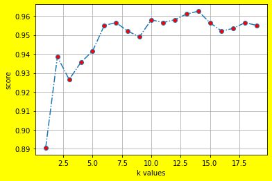

```python
fig = plt.figure()
fig.patch.set_facecolor('yellow')
plt.plot(range(1,20), score, marker='o', markerfacecolor='r', linestyle='-.')
plt.xlabel("k values")
plt.ylabel("score")
plt.grid()
```

```python
# Model building and fitting
rfc=RandomForestClassifier(n_estimators=14)
rfc.fit(scaled_X_train,y_train)
```

```
RandomForestClassifier(n_estimators=14)
```

```python
# Prediction on  training data
train_pred_2 = rfc.predict(scaled_X_train)
print("Prediction on training data\n",train_pred_2)

# Prediction on  testing data
test_pred_2 = rfc.predict(scaled_X_test)
print("\nPrediction on testing data\n",test_pred_2)
```

```
Prediction on training data
 [0 0 0 ... 0 0 0]

Prediction on testing data
 [0 0 0 0 1 0 0 0 1 0 0 0 0 0 0 0 0 0 1 0 0 0 0 0 0 0 0 0 0 0 0 0 0 0 0 0 0
 0 0 0 0 0 0 0 1 0 0 0 0 1 1 0 0 0 0 0 0 1 0 0 0 0 0 0 0 0 0 0 0 1 0 0 1 1
 0 0 0 0 0 0 0 0 0 0 0 0 0 0 1 0 0 0 0 0 0 0 0 0 0 0 0 0 0 0 0 0 0 0 0 0 0
 0 0 0 0 0 0 0 0 0 0 0 0 0 0 0 0 1 0 0 1 0 0 0 0 0 0 0 0 0 0 0 0 0 0 0 0 0
 1 0 0 0 0 0 0 0 0 0 0 0 0 0 0 0 0 0 0 0 0 0 0 0 0 1 0 1 0 0 0 0 0 0 0 1 1
 0 0 0 0 0 0 0 0 0 1 0 1 0 0 0 0 1 0 0 0 0 0 0 1 0 0 1 0 0 0 0 0 1 0 0 1 0
 0 1 0 0 0 0 0 0 0 0 0 0 0 0 0 0 0 0 0 1 0 0 0 0 0 0 0 1 0 0 0 0 1 0 0 0 1
 0 1 0 0 0 0 0 0 0 0 0 0 0 0 0 0 0 0 0 0 0 0 0 0 0 0 0 0 0 0 0 0 0 0 0 0 0
 0 0 0 0 1 0 0 1 0 0 1 1 0 0 1 0 0 0 1 0 0 0 0 0 0 0 0 0 0 0 0 0 1 0 0 1 1
 0 0 0 0 0 0 0 0 0 0 1 0 0 0 0 0 0 0 0 0 0 0 0 0 1 0 0 0 0 0 0 0 0 0 0 0 1
 0 0 0 0 0 0 0 0 0 0 0 0 0 0 0 0 0 0 0 0 0 0 0 0 0 0 1 0 0 0 0 0 0 0 0 0 0
 0 1 0 0 0 0 0 0 0 0 0 0 0 0 0 0 0 0 0 0 0 0 0 0 0 0 0 1 0 0 0 0 0 0 0 0 0
 0 0 0 0 0 0 0 0 0 0 0 0 0 0 0 0 1 0 0 0 1 0 0 0 0 0 0 0 0 0 0 0 0 0 1 1 0
 0 1 0 0 0 0 0 0 0 1 0 0 0 0 0 0 1 0 0 0 0 0 0 0 0 0 0 0 0 0 0 0 0 0 0 0 1
 0 0 0 0 0 0 1 0 0 0 0 1 0 0 0 0 0 0 0 0 0 0 1 0 0 0 0 0 0 1 0 0 0 0 0 0 0
 0 0 0 0 0 0 0 1 0 0 0 0 0 0 0 0 0 0 0 0 0 0 0 0 1 0 0 0 0 0 0 0 0 0 0 1 0
 0 0 0 0 0 1 0 0 0 0 0 0 0 0 0 0 0 0 0 0 0 0 0 0 0 0 0 0 1 0 0 0 0 0 0 1 0
 1 0 0 0 0 0 0 0 1 0 0 1 1 0 0 0 0 0 0 0 0 0 0 0 0 1 0 1 0 0 0 0 0 0 0 0 0
 0]
```

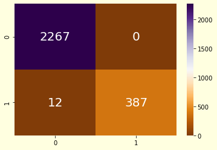

```python
# Confusion matrix for training data
fig = plt.figure()
fig.patch.set_facecolor('lightyellow')
sns.heatmap(confusion_matrix(y_train, train_pred_2), annot=True,fmt='d', annot_kws={'size':20},cmap="PuOr")
```

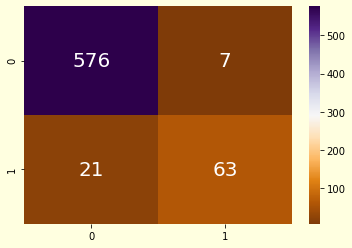

```python
# Confusion matrix for testing data
fig = plt.figure()
fig.patch.set_facecolor('lightyellow')
sns.heatmap(confusion_matrix(y_test, test_pred_2), annot=True,fmt='d', annot_kws={'size':20},cmap="PuOr")
```

```python
# Classification report for training and testing data
print("Classification Report for Training Data\n",classification_report(y_train, train_pred_2))
print("\nClassification Report for Test Data\n",classification_report(y_test, test_pred_2))
```

```
Classification Report for Training Data
               precision    recall  f1-score   support

           0       0.99      1.00      1.00      2267
           1       1.00      0.97      0.98       399

    accuracy                           1.00      2666
   macro avg       1.00      0.98      0.99      2666
weighted avg       1.00      1.00      1.00      2666


Classification Report for Test Data
               precision    recall  f1-score   support

           0       0.96      0.99      0.98       583
           1       0.90      0.75      0.82        84

    accuracy                           0.96       667
   macro avg       0.93      0.87      0.90       667
weighted avg       0.96      0.96      0.96       667
```

- **As the output column is imbalanced, we consider f1-score**
  - Train : 100%
  - Test : 96%

```
0.933257779955893
```

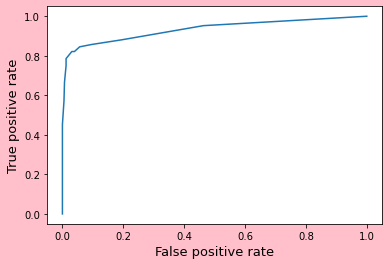

```python
# roc_auc curve for random-forest classifier
fig = plt.figure()
fig.patch.set_facecolor('pink')
k_prob=rfc.predict_proba(scaled_X_test)[:,1]
fpr,tpr,threshold=roc_curve(y_test,k_prob,pos_label=1)

plt.plot(fpr,tpr)
plt.xlabel("False positive rate",fontsize=13)
plt.ylabel("True positive rate",fontsize=13)
rfc_r=roc_auc_score(y_test,k_prob)
print(rfc_r)
```

## Hyperparameter Tuning

### - **GridSearchCV**

```python
# Listing the parameters
param_grid = {'max_features': ['auto', 'sqrt', 'log2'], 'max_depth' : [4,5,6,7,8], 'criterion':['gini', 'entropy']}
```

```python
# Finding the best parameters
CV_rfc = GridSearchCV(estimator=rfc, param_grid=param_grid, cv= 5)
CV_rfc.fit(scaled_X_train, y_train)

print(CV_rfc.best_params_)
```

```
{'criterion': 'gini', 'max_depth': 8, 'max_features': 'sqrt'}
```

```python
# Model building with best parameters and fitting the model
rfc1=RandomForestClassifier(random_state=42, max_features='sqrt', n_estimators= 14, max_depth=8, criterion='gini')
rfc1.fit(scaled_X_train, y_train)
```

```
RandomForestClassifier(max_depth=8, max_features='sqrt', n_estimators=14,
                       random_state=42)
```

```python
# Prediction on traning data
train_pred_3=rfc1.predict(scaled_X_train)
print("Prediction on training data\n",train_pred_3)

# Prediction on testing data
test_pred_3=rfc1.predict(scaled_X_test)
print("\nPrediction on testing data\n",test_pred_3)
```

```
Prediction on training data
 [0 0 0 ... 0 0 0]

Prediction on testing data
 [0 0 0 0 1 0 0 0 1 0 0 0 0 0 0 0 0 0 1 0 0 0 0 0 0 0 0 0 0 0 0 0 0 0 0 0 0
 0 0 0 0 0 0 0 0 0 0 0 0 1 1 0 0 0 0 0 0 1 0 0 0 0 0 0 0 0 0 0 0 1 0 0 1 1
 0 0 0 0 0 0 0 0 0 0 0 0 0 0 1 0 0 0 0 0 0 0 0 0 0 0 0 0 0 0 0 0 0 0 0 0 0
 0 0 0 0 0 0 0 0 0 0 0 0 0 0 0 0 1 0 0 1 0 0 0 0 0 0 0 0 0 0 0 0 0 0 0 0 0
 1 0 0 0 0 0 0 0 0 0 0 0 0 0 0 0 0 0 1 0 0 1 0 0 0 1 0 1 0 0 0 0 0 0 0 1 1
 0 0 0 0 0 0 0 0 0 1 0 0 0 0 0 0 1 0 0 0 0 0 0 1 0 0 1 0 0 0 0 0 1 0 0 1 0
 0 1 0 0 1 0 0 0 0 0 0 0 0 0 0 0 0 0 0 1 0 0 0 0 0 0 0 1 0 0 0 0 1 0 0 0 1
 0 1 0 0 0 0 0 0 0 0 0 0 0 0 0 0 0 0 0 0 0 0 0 0 0 0 0 0 0 0 0 0 0 0 0 0 0
 0 0 0 0 1 0 0 1 0 0 1 1 0 0 1 0 0 0 0 0 0 0 0 0 0 0 0 0 0 0 0 0 1 0 0 1 1
 0 0 0 0 0 0 0 0 0 0 1 0 0 0 0 0 0 0 0 0 0 0 0 0 1 0 0 0 0 0 0 0 0 0 0 0 1
 0 0 0 0 0 0 0 0 0 0 0 0 0 1 0 1 0 0 0 0 0 0 0 0 0 0 1 0 0 0 0 0 0 0 0 0 0
 0 1 0 0 0 0 0 0 0 0 0 0 0 0 0 0 0 0 0 0 0 0 0 0 0 0 0 1 0 0 0 0 0 0 0 0 0
 0 0 0 0 0 0 0 0 0 0 0 0 0 0 0 0 0 0 0 0 0 0 0 0 0 0 0 0 0 0 0 0 0 0 1 1 0
 0 1 0 0 0 0 0 0 0 1 0 0 0 0 0 0 1 0 0 0 0 0 0 0 0 0 0 0 0 0 0 0 0 0 0 0 1
 0 0 0 0 0 0 1 0 0 0 0 1 0 0 0 0 0 0 0 0 0 0 1 0 0 0 0 0 0 1 0 0 0 0 0 0 0
 0 0 0 0 1 0 0 1 0 0 0 0 0 0 0 0 0 0 0 0 0 0 0 0 1 0 0 0 0 0 0 0 0 0 0 1 0
 0 0 0 0 0 1 0 0 0 0 0 0 0 0 0 0 0 0 0 0 0 0 0 0 0 0 0 0 1 0 0 0 0 0 0 0 0
 1 0 0 0 0 0 0 0 1 0 0 1 1 0 0 0 0 0 0 0 0 0 0 0 0 1 0 1 0 0 0 0 0 0 0 0 0
 0]
```

```python
# Classification report on training and test data
print("Classification report on training data:\n",classification_report(y_train,train_pred_3))
print("\nClassification report on testing data:\n",classification_report(y_test,test_pred_3))
```

```
Classification report on training data:
               precision    recall  f1-score   support

           0       0.97      1.00      0.99      2267
           1       1.00      0.84      0.91       399

    accuracy                           0.98      2666
   macro avg       0.98      0.92      0.95      2666
weighted avg       0.98      0.98      0.97      2666


Classification report on testing data:
               precision    recall  f1-score   support

           0       0.96      0.98      0.97       583
           1       0.87      0.73      0.79        84

    accuracy                           0.95       667
   macro avg       0.92      0.86      0.88       667
weighted avg       0.95      0.95      0.95       667
```

- **As the output column is imbalanced, we consider f1-score accuracy**
  - Train : 98%
  - Test : 95%

```
0.933257779955893
```

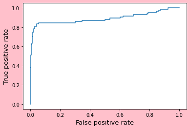

```python
# roc_auc curve after applying hyper-parameter tuning for RFC
fig = plt.figure()
fig.patch.set_facecolor('pink')
k1_prob=rfc1.predict_proba(scaled_X_test)[:,1]
fpr,tpr,threshold=roc_curve(y_test,k1_prob,pos_label=1)

plt.plot(fpr,tpr)
plt.xlabel("False positive rate",fontsize=13)
plt.ylabel("True positive rate",fontsize=13)
rfc_CV_r=roc_auc_score(y_test,k_prob)
print(rfc_CV_r)
```

- Decision Tree Classifier

  A decision tree is a flowchart-like tree structure where an internal node represents feature(or attribute), the branch represents a decision rule, and each leaf node represents the outcome. The topmost node in a decision tree is known as the root node.

```python
# Apply the Decision Tree Algorithm
dtree = DecisionTreeClassifier()
dtree.fit(scaled_X_train, y_train)
```

```
DecisionTreeClassifier()
```

```python
# Predict on training data and testing data
train_pred_4 = dtree.predict(scaled_X_train)
print("Prediction on training data\n",train_pred_4)

test_pred_4 =  dtree.predict(scaled_X_test)
print("\nPrediction on testing data\n",test_pred_4)
```

```
Prediction on training data
 [0 0 0 ... 0 0 0]

Prediction on testing data
 [0 0 1 0 1 0 0 0 1 0 0 0 0 0 0 0 0 0 1 0 0 0 0 0 0 0 0 0 0 0 0 0 0 0 0 0 0
 0 0 0 0 0 0 0 1 0 0 0 0 1 1 0 0 1 0 1 0 1 0 0 0 0 0 1 0 0 0 0 0 1 0 0 1 1
 0 0 0 0 0 0 0 0 0 0 0 0 0 0 1 0 0 1 0 0 0 0 0 0 0 0 0 0 0 0 0 1 0 0 0 0 0
 0 0 0 0 0 0 0 0 0 0 0 0 0 0 0 0 0 0 0 1 0 0 0 0 0 0 0 0 0 0 0 0 0 0 0 0 0
 1 0 0 0 0 0 0 0 0 0 0 0 0 1 0 0 1 0 1 0 0 0 0 0 0 1 0 1 0 0 0 0 0 0 0 1 1
 0 0 0 0 0 0 0 0 0 1 1 1 0 0 0 0 1 0 0 0 0 0 0 1 0 0 0 0 0 0 0 1 1 0 0 1 0
 0 1 1 0 1 0 0 0 0 0 0 0 0 0 0 0 0 0 0 1 0 0 0 0 0 0 0 1 0 0 0 0 1 0 0 0 1
 0 1 0 0 0 0 0 0 0 0 0 0 0 0 0 0 0 0 0 0 0 0 0 0 0 0 0 0 0 0 0 0 0 0 0 0 0
 0 0 1 0 0 0 0 1 0 0 1 1 0 0 1 0 0 0 1 0 0 0 1 0 0 0 0 0 0 0 0 0 1 0 0 1 1
 0 0 0 0 0 0 0 0 0 0 1 0 0 0 0 0 0 0 1 0 0 0 0 0 1 1 0 0 0 0 0 0 0 0 0 0 1
 0 0 0 0 0 1 0 0 0 0 0 0 0 1 0 1 1 0 0 0 0 0 0 0 0 0 0 0 0 0 0 0 0 0 0 0 0
 0 0 0 0 0 0 0 0 0 0 0 0 0 0 0 0 0 0 1 0 0 0 0 0 0 0 0 1 0 0 0 0 0 0 0 0 0
 0 0 0 0 0 0 0 0 0 0 0 0 0 0 0 0 1 0 0 0 1 0 0 0 0 0 0 0 0 0 0 0 0 1 1 1 0
 0 1 0 0 0 0 0 0 0 1 0 0 0 0 1 0 1 0 0 0 0 0 0 0 0 0 0 0 0 0 0 0 0 0 0 0 1
 0 0 0 1 0 0 1 0 0 0 0 1 0 0 0 0 0 0 0 0 0 0 1 0 1 0 0 0 0 1 0 0 0 0 0 0 0
 0 0 0 0 1 0 0 1 0 0 1 0 0 0 0 0 1 0 0 0 0 0 0 0 0 0 0 0 0 0 0 0 0 0 0 0 0
 0 0 0 0 0 1 0 0 0 0 0 0 0 0 0 0 0 0 0 0 0 0 0 0 0 0 0 0 1 0 0 0 0 0 0 1 0
 0 0 0 0 0 0 0 0 1 0 0 1 1 0 0 0 0 0 0 0 0 0 0 0 1 1 1 1 0 0 0 0 0 0 0 1 0
 0]
```

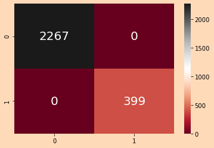

```python
# CONFUSION MATRIX FOR TRAINING DATA
fig = plt.figure()
fig.patch.set_facecolor('peachpuff')
sns.heatmap(confusion_matrix(y_train, train_pred_4), annot=True,fmt='d', annot_kws={'size':20},cmap="RdGy")
```

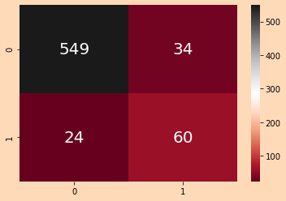

```python
# CONFUSION MATRIX FOR TEST DATA
fig = plt.figure()
fig.patch.set_facecolor('peachpuff')
sns.heatmap(confusion_matrix(y_test, test_pred_4), annot=True,fmt='d', annot_kws={'size':20},cmap="RdGy")
```

```python
# Classification Report on training data and testing data

print("Classification Report on training data\n",classification_report(y_train, train_pred_4))
print("\nClassification Report on testing data\n",classification_report(y_test, test_pred_4))
```

```
Classification Report on training data
               precision    recall  f1-score   support

           0       1.00      1.00      1.00      2267
           1       1.00      1.00      1.00       399

    accuracy                           1.00      2666
   macro avg       1.00      1.00      1.00      2666
weighted avg       1.00      1.00      1.00      2666


Classification Report on testing data
               precision    recall  f1-score   support

           0       0.96      0.94      0.95       583
           1       0.64      0.71      0.67        84

    accuracy                           0.91       667
   macro avg       0.80      0.83      0.81       667
weighted avg       0.92      0.91      0.92       667
```

- **As the output column is imbalanced, we consider f1-score**
  - Train : 100%
  - Test : 91%

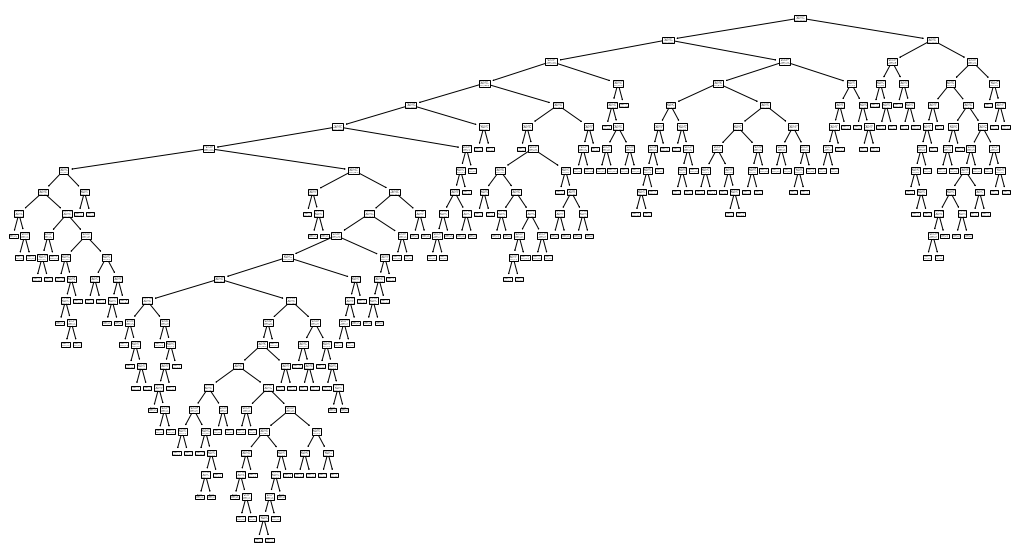

```python
# Visualization of the Decision Tree
import sklearn
from sklearn import tree
plt.figure(figsize=(18,10))
sklearn.tree.plot_tree(dtree)
plt.show()
```

- **KFOLD CV**

```python
# Checking the KFOLD Cross-validation scores
cross_val_score(dtree, scaled_X_train, y_train, cv =5)
```

```
array([0.90262172, 0.90243902, 0.91181989, 0.90619137, 0.91932458])
```

```
0.8279833374172998
```

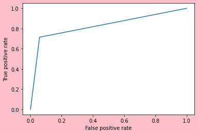

```python
# roc_auc curve for Decision-Tree classifier
fig = plt.figure()
fig.patch.set_facecolor('pink')
d_prob=dtree.predict_proba(scaled_X_test)[:,1]
fpr,tpr,threshold=roc_curve(y_test,d_prob,pos_label=1)

plt.plot(fpr,tpr)
plt.xlabel("False positive rate")
plt.ylabel("True positive rate")
dtc_r=roc_auc_score(y_test,d_prob)
print(dtc_r)
```

## EVALUATION

### From the above algorithms , we can see ...

**1. K-Nearest-Neighbors Classifier**

- Training accuracy = 92%
- Testing accuracy = 91%
- AUC_ROC score = 83%

**3. Decision tree Classifier**

- Training accuracy = 100%
- Testing accuracy = 91%
- AUC_ROC score = 82%

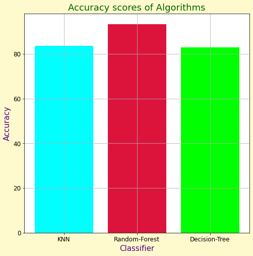

```python
# Plot for comparision b/w all algorithms
acuuracy_scores=[knn_r*100,rfc_r*100,dtc_r*100]
plt.figure(figsize=(8,8),facecolor='lemonchiffon')
colors=['cyan','crimson','lime']
labels=['KNN','Random-Forest','Decision-Tree']
plt.bar(labels,acuuracy_scores,color=colors)
plt.title("Accuracy scores of Algorithms",fontsize=18,color='darkgreen')
plt.xlabel("Classifier",fontsize=15,color='indigo')
plt.ylabel("Accuracy",fontsize=15,color='indigo')
plt.xticks(fontsize=12)
plt.yticks(fontsize=12)
plt.grid()
plt.show()
```

## CONCLUSION

### From the above observations we can conclude that RANDOM FOREST CLASSIFIER is best model to predict the Churn Prediction problem statement.

```python
# Checking the model with unknown data
```

```python
print(rfc.predict([[2.020032,-0.516575,1.330827,1.596851,1.149814,-0.964363,0.174083,-0.964098,-1.142860,1.346251,-1.142685,-0.193665,-0.115917,-0.195905,0.486386,-0.596466,0.483108,-0.429585]]))
```

```
[0]
```